# Predicting Housing Prices for Mecklenberg County, NC - MUSA508 Midterm

Rui Jiang, Jingyi Cai

2022-09-25

# I. Introduction

Zillow has realized that its housing market predictions are not as accurate as they could be because they do not factor in enough local intelligence. As such they have asked us to build a better predictive model of home prices for Mecklenberg County, NC. This model aims to build an accurate and generalizable hedonic model that predicts home prices for Mecklenberg County, NC by deconstructing overall home price into the value of constituent parts. Accurate models lead to only small differences between the predicted and observed values, and generalizable models accurately predict on new data and with comparable accuracy across various groups. By working to improve the accuracy and generalizability of the predictive model, we are ultimately striving to create a more useful decision-making tool. Such a model may be useful for local governments as they assess property taxes, for example.

# II. Data Manipulation and Visualization

## 2.0 Setup

In this section, we loaded necessary libraries, created plot theme options and map theme options, and identified functions of quintile breaks, and average nearest neighbor distance for further analysis.

```r
# Load some libraries

library(tidyverse)
library(sf)
library(spdep)
library(caret)
library(ckanr)
library(FNN)
library(grid)
library(gridExtra)
library(ggcorrplot) # plot correlation plot
library(corrr)      # another way to plot correlation plot
library(kableExtra)
library(jtools)     # for regression model plots
library(ggstance) # to support jtools plots
library(ggpubr)    # plotting R^2 value on ggplot point scatter
library(broom.mixed) # needed for effects plots
library(tidycensus)
library(geojsonio)
library(stargazer)
library(utils)
library(rgdal)
#library(plyr)

# functions and data directory
root.dir = "https://raw.githubusercontent.com/urbanSpatial/Public-Policy-Analytics-Landing/master/DATA/"

source("https://raw.githubusercontent.com/urbanSpatial/Public-Policy-Analytics-Landing/master/functions.r")

palette5 <- c("#25CB10", "#5AB60C", "#8FA108",   "#C48C04", "#FA7800")
```

## 2.1 Data Wrangling

In this section, we loaded Mecklenburg County data and other complementary datasets and conducted feature selection and engineering. Besides, for other analyses, we separate the whole dataset into and in advance of Mecklenburg.

Five categorical datasets were used in this project: **Mecklenburg County House Price and Internal Characteristics:** basic geometric dataset provided by the course in advance.

**• TotalPop:** Total population in each census tract  
**• Whites:** White population in each census tract  
**• MedHHInc:** Median household income in each census tract  
**• MedRent:** Median Rent for properties in each census tract  
**• TotalPoverty:** Population living under the level of poverty in each census tract  
**• TotalUnit:** Total housing units in each census tract  
**• pctWhite:** white population proportion in each census tract  
**• pctBachelors:** Bachelor population proportion in each census tract  
**• pctPoverty:** Poverty population proportion in each census tract  
**• pctTotalVacant:** Vacant unites proportion in each census tract

**Amenity Data:** most of the data come from the website of government: http://maps.co.mecklenburg.nc.us/openmapping/data.html.Compilatory data were chosen for describing amenities and public services of Mecklenburg County. The datasets we chose encompasses fireplace, police station, education opportunity, healthcare service, and entertainment accessibility. See each dataset below:

**1. Public School:** Dataset contains points representing Elementary, Middle, and High Schools in Mecklenburg County.  
**2. Bus station:** A point feature class of CATS Bus Stops for Mecklenburg County.  
**3. Fire station :** Geographical representation of the physical locations of the Charlotte Fire Department Fire Stations.  
**4. Church :** Churches dataset defines locations classified as religious organizations in Mecklenburg County, data is queried from Master Address Table.  
**5. Medical Facilities:** This dataset was generated to publish a geospatial inventory of Medical Facilities in Mecklenburg County, NC. This data serves to support and assist the Charlotte Mecklenburg Planning Department, The City of Charlotte, and others in Urban Planning decisions.  
**6. Park :** Park amenities for all parks in Mecklenburg County, including Charlotte, Davidson, Cornelius, Davidson, Huntersville, Matthews, Mint Hill, and Pineville.  
**7. Police:** Charlotte-Mecklenburg Police Department Stations.

```r
primary.data<-
  st_read("https://raw.githubusercontent.com/mafichman/MUSA_508_Lab/main/Midterm/data/2022/studentData.geojson")%>%
  st_transform('EPSG:2264')
```

```r
primary.data<-
  primary.data%>%
  filter(price<10000000)

mklb.sf <-
  primary.data %>%
  st_as_sf(coords = c("Longitude", "Latitude"), crs = 2264, agr = "constant") %>%
  st_transform('EPSG:2264') %>%
  mutate(storyheigh = as.numeric(gsub(" STORY", "", primary.data$storyheigh))
  )

mklb.sf<-
  mklb.sf %>%
  mutate(age=2022-yearbuilt,prisqft =price/heatedarea)%>%
  dplyr::select(commonpid,price,age,storyheigh,heatedarea,numfirepla,totalac,
                fullbaths,halfbaths,bedrooms,units,toPredict,prisqft)

numericVars <-
  select_if(st_drop_geometry(mklb.sf), is.numeric) %>% na.omit()
```

```r
#school data
cmpd_school<-
  st_read('https://raw.githubusercontent.com/RumRon/MUSA_508/main/Midterm/geojson/CMS_Schools.geojson') %>%
  st_transform('EPSG:2264')

# firestation
cmpd_firestation<-
  st_read('https://raw.githubusercontent.com/RumRon/MUSA_508/main/Midterm/geojson/CFD_FireStations.geojson') %>%
  st_transform('EPSG:2264')

# church
cmpd_church<-
  st_read('https://raw.githubusercontent.com/RumRon/MUSA_508/main/Midterm/geojson/Churches.geojson') %>%
  st_transform('EPSG:2264')

# medical facilities
cmpd_medical<-
  st_read('https://raw.githubusercontent.com/RumRon/MUSA_508/main/Midterm/geojson/MedicalFacilities.geojson') %>%
  st_transform('EPSG:2264')
# park
cmpd_park<-
  st_read('https://raw.githubusercontent.com/RumRon/MUSA_508/main/Midterm/geojson/Park_Locations.geojson') %>%
  st_transform('EPSG:2264')
# police
cmpd_police<-
  st_read('https://raw.githubusercontent.com/RumRon/MUSA_508/main/Midterm/geojson/CMPD_Police_Offices.geojson') %>%
  st_transform('EPSG:2264')

# bus
cmpd_busstation<-
  st_read('https://raw.githubusercontent.com/RumRon/MUSA_508/main/Midterm/geojson/CATS_BusStops.geojson') %>%
  st_transform('EPSG:2264')

#neighborhood
neighborhood <-
  st_read('https://raw.githubusercontent.com/RumRon/HW_UP_IP/main/Midterm/geojson/VFD_FireDistricts.geojson')%>%
  st_transform('EPSG:2264')
```

```r
police.sf <-
  cmpd_police %>%
    dplyr::select(name) %>%
    #na.omit() %>%
    st_zm(drop = TRUE) %>%
    st_as_sf(coords = c("Longitude", "Latitude"), crs = "EPSG:2264") %>%
    st_transform('EPSG:2264') %>%
    distinct()

bus.sf<-
  cmpd_busstation %>%
    dplyr::select(StopID) %>%
    na.omit() %>%
    st_zm(drop = TRUE) %>%
    st_as_sf(coords = c("Longitude", "Latitude"), crs = "EPSG:2264") %>%
    st_transform('EPSG:2264') %>%
    distinct()

church.sf<-
  cmpd_church %>%
    dplyr::select(num_parent) %>%
    #na.omit() %>%
    st_zm(drop = TRUE) %>%
    st_as_sf(coords = c("Longitude", "Latitude"), crs = "EPSG:2264") %>%
    st_transform('EPSG:2264') %>%
    distinct()


firestation.sf<-
  cmpd_firestation %>%
    dplyr::select(NAME) %>%
    #na.omit() %>%
    st_zm(drop = TRUE) %>%
    st_as_sf(coords = c("Longitude", "Latitude"), crs = "EPSG:2264") %>%
    st_transform('EPSG:2264') %>%
    distinct()

medical.sf<-
  cmpd_medical %>%
    dplyr::select(Name) %>%
    #na.omit() %>%
    st_zm(drop = TRUE) %>%
    st_as_sf(coords = c("Longitude", "Latitude"), crs = "EPSG:2264") %>%
    st_transform('EPSG:2264') %>%
    distinct()

park.sf<-
  cmpd_park %>%
    dplyr::select(prkname) %>%
    #na.omit() %>%
    st_zm(drop = TRUE) %>%
    st_as_sf(coords = c("Longitude", "Latitude"), crs = "EPSG:2264") %>%
    st_transform('EPSG:2264') %>%
    distinct()

school.sf<-
  cmpd_school %>%
    dplyr::select(school) %>%
    #na.omit() %>%
    st_zm(drop = TRUE) %>%
    st_as_sf(coords = c("Longitude", "Latitude"), crs = "EPSG:2264") %>%
    st_transform('EPSG:2264') %>%
    distinct()

nhood.sf<-
  neighborhood %>%
  dplyr::select(vfd) %>%
  #filter(name != NA)%>%
  st_zm(drop = TRUE) %>%
  st_as_sf(coords = c("Longitude", "Latitude"), crs = "EPSG:2264") %>%
  st_transform('EPSG:2264') %>%
  distinct()
```

```r
mklb.sf <-
  mklb.sf %>%
     mutate(
       police_nn1 = nn_function(st_coordinates(mklb.sf),
                                st_coordinates(police.sf), k = 1),
       police_nn2 = nn_function(st_coordinates(mklb.sf),
                                st_coordinates(police.sf), k = 2),
       police_nn3 = nn_function(st_coordinates(mklb.sf),
                                st_coordinates(police.sf), k = 3),
       school_nn1 = nn_function(st_coordinates(mklb.sf),
                              st_coordinates(school.sf), k = 1),
       school_nn2 = nn_function(st_coordinates(mklb.sf),
                              st_coordinates(school.sf), k = 2),
       school_nn3 = nn_function(st_coordinates(mklb.sf),
                              st_coordinates(school.sf), k = 3),
       park_nn1 = nn_function(st_coordinates(mklb.sf),
                              st_coordinates(park.sf), k = 1),
       park_nn2 = nn_function(st_coordinates(mklb.sf),
                              st_coordinates(park.sf), k = 2),
       park_nn3 = nn_function(st_coordinates(mklb.sf),
                              st_coordinates(park.sf), k = 3),
       firestation_nn1 = nn_function(st_coordinates(mklb.sf),
                              st_coordinates(firestation.sf), k = 1),
       firestation_nn2 = nn_function(st_coordinates(mklb.sf),
                              st_coordinates(firestation.sf), k = 2),
       firestation_nn3 = nn_function(st_coordinates(mklb.sf),
                              st_coordinates(firestation.sf), k = 3),
       church_nn1 = nn_function(st_coordinates(mklb.sf),
                              st_coordinates(church.sf), k = 1),
       church_nn2 = nn_function(st_coordinates(mklb.sf),
                              st_coordinates(church.sf), k = 2),
       church_nn3 = nn_function(st_coordinates(mklb.sf),
                              st_coordinates(church.sf), k = 3),
       medical_nn1 = nn_function(st_coordinates(mklb.sf),
                              st_coordinates(medical.sf), k = 1),
       medical_nn2 = nn_function(st_coordinates(mklb.sf),
                              st_coordinates(medical.sf), k = 2),
       medical_nn3 = nn_function(st_coordinates(mklb.sf),
                              st_coordinates(medical.sf), k = 3))

mklb.sf <-st_join(mklb.sf, nhood.sf)
```

```r
# acs
acs_variable_list.20 <- load_variables(2020, #year
                                         "acs5", #five year ACS estimates
                                         cache = TRUE)
tracts20 <-
  get_acs(geography = "tract", variables = c("B25026_001E","B02001_002E","B15001_050E",
                                             "B15001_009E","B19013_001E","B25058_001E",
                                             "B06012_002E","B28010_007E","B08101_001E",
                                             "B09001_001E","B09001_003E","B09021_002E",
                                             "B11001I_001E", "B14001_009E",
                                             "B17001_002E","B27001_001E","B18101_001E",
                                             "B19001_001E","B25001_001E","B25040_001E"),
          year=2020, state=37, county=119, geometry=T, output="wide") %>%
  st_transform('EPSG:2264') %>%
  mutate(TotalPop = B25026_001E,
         Whites = B02001_002E,
         FemaleBachelors = B15001_050E,
         MaleBachelors = B15001_009E,
         MedHHInc = B19013_001E,
         MedRent = B25058_001E,
         TotalPoverty = B06012_002E,
         Nocom = B28010_007E,
         Waytowork = B08101_001E,
         Popunder18 = B09001_001E,
         Popunder3 = B09001_003E,
         Singleadult = B09021_002E,
         Householdtype = B11001I_001E,
         Addmittogra = B14001_009E,
         Poverty  = B17001_002E,
         Healthins  = B27001_001E,
         Disable  = B18101_001E,
         Familyincome  = B19001_001E,
         Housingunits  = B25001_001E,
         Househeatingfuel  = B25040_001E)%>%
  mutate(pctWhite = ifelse(TotalPop > 0, Whites / TotalPop,0),
         pctBachelors = ifelse(TotalPop > 0, ((FemaleBachelors + MaleBachelors) / TotalPop),0),
         pctPoverty = ifelse(TotalPop > 0, TotalPoverty / TotalPop, 0),
         year = "2020")
```

## 2.2 Summary Statistics

Present a table of summary statistics with variable descriptions. We sort these variables by their category (internal characteristics, amenities/public services or spatial structure).

```r
#internal
factor_internal <- mklb.sf%>%
  dplyr::select(commonpid,price,age,storyheigh,heatedarea,numfirepla,totalac,
                fullbaths,halfbaths,bedrooms,units,prisqft) %>%
  filter(prisqft!= 'Inf')

factor_internal.sf <- factor_internal

factor_internal <-
  select_if(st_drop_geometry(factor_internal), is.numeric)  %>% na.omit()
#amentities
factor_amenity <- mklb.sf%>%
  dplyr::select(price,prisqft,police_nn1, police_nn2, police_nn3, school_nn1, school_nn2,  school_nn3, church_nn1, church_nn2, church_nn3, park_nn1, park_nn2, park_nn3,firestation_nn1, firestation_nn2, firestation_nn3, medical_nn1, medical_nn2, medical_nn3,police_nn1, police_nn2, police_nn3)

factor_amenity <- factor_amenity%>%filter(prisqft!= 'Inf')
  # dplyr::select(-commonpid,-age,-storyheigh,-heatedarea,-numfirepla,-totalac,
  #                -fullbaths,-halfbaths,-bedrooms,-units)

factor_amenity.sf <- factor_amenity
factor_amenity <-
  select_if(st_drop_geometry(factor_amenity), is.numeric)  %>% na.omit()
#ACS
ACS1 <- mklb.sf%>%
  dplyr::select(price,prisqft)

ACS2 <- tracts20%>%
  dplyr::select(pctWhite, pctBachelors, pctPoverty, TotalPop, MedHHInc, Singleadult, Healthins, Familyincome, Housingunits, Househeatingfuel)

factor_acs <-st_join(ACS1, ACS2) #%>%
  #distinct(geometry, .keep_all = TRUE)

all.sf <-st_join(mklb.sf, ACS2)

factor_acs <-factor_acs%>%filter(prisqft!= 'Inf')
factor_acs.sf <- factor_acs
factor_acs <-
  select_if(st_drop_geometry(factor_acs), is.numeric) %>% na.omit()


star_internal <- st_drop_geometry(factor_internal)
star_amenity <- st_drop_geometry(factor_amenity)
star_acs <- st_drop_geometry(factor_acs)




star_internal <- st_drop_geometry(factor_internal)
star_amenity <- st_drop_geometry(factor_amenity)
star_acs <- st_drop_geometry(factor_acs)

stargazer(star_internal, type = "html",
          title = "Table DATA 2.1 Summary Statistics of Internal Characteristics ",
          header = FALSE,
          #out = "try.html",
          single.row = TRUE)
```

**Table DATA 2.1 Summary Statistics of Internal Characteristics**

| Statistic | N | Mean | St. Dev. | Min | Max |
| --- | --- | --- | --- | --- | --- |
| price | 44,596 | 462,928.900 | 377,354.600 | 0 | 7,700,000 |
| age | 44,596 | 27.656 | 25.838 | 0 | 2,022 |
| storyheigh | 44,596 | 1.646 | 0.484 | 1.000 | 3.000 |
| heatedarea | 44,596 | 2,367.630 | 1,070.427 | 306.000 | 14,710.000 |
| numfirepla | 44,596 | 0.787 | 0.466 | 0 | 7 |
| totalac | 44,596 | 1.826 | 108.598 | 0.000 | 9,757.440 |
| fullbaths | 44,596 | 2.284 | 0.829 | 0 | 9 |
| halfbaths | 44,596 | 0.602 | 0.527 | 0 | 4 |
| bedrooms | 44,596 | 3.512 | 0.950 | 0 | 65 |
| units | 44,596 | 0.976 | 0.199 | 0 | 8 |
| prisqft | 44,596 | 195.697 | 107.364 | 0.000 | 5,080.808 |

```r
stargazer(star_amenity, type = "html",
          title = "Table DATA 2.2 Summary Statistics of Amenities Characteristics ",
          header = FALSE,
          #out = "try.html",
          single.row = TRUE)
```

**Table DATA 2.2 Summary Statistics of Amenities Characteristics**

| Statistic | N | Mean | St. Dev. | Min | Max |
| --- | --- | --- | --- | --- | --- |
| price | 46,201 | 461,394.900 | 373,709.800 | 0 | 7,700,000 |
| prisqft | 46,201 | 195.586 | 106.372 | 0.000 | 5,080.808 |
| police_nn1 | 46,201 | 19,759.000 | 11,646.630 | 232.622 | 60,796.570 |
| police_nn2 | 46,201 | 24,973.550 | 13,360.550 | 1,689.842 | 72,490.110 |
| police_nn3 | 46,201 | 28,464.720 | 14,531.070 | 5,592.504 | 79,044.680 |
| school_nn1 | 46,201 | 4,763.712 | 3,075.632 | 116.992 | 22,481.340 |
| school_nn2 | 46,201 | 5,883.655 | 3,092.816 | 116.992 | 22,972.960 |
| school_nn3 | 46,201 | 6,949.664 | 3,335.845 | 634.527 | 24,897.730 |
| church_nn1 | 46,201 | 2,932.691 | 2,097.287 | 17.465 | 14,635.710 |
| church_nn2 | 46,201 | 3,469.833 | 2,208.135 | 42.527 | 16,387.490 |
| church_nn3 | 46,201 | 3,929.411 | 2,308.243 | 113.048 | 17,229.310 |
| park_nn1 | 46,201 | 4,069.461 | 2,518.566 | 68.884 | 16,490.430 |
| park_nn2 | 46,201 | 4,977.050 | 2,588.607 | 205.557 | 16,614.240 |
| park_nn3 | 46,201 | 5,711.460 | 2,679.841 | 294.621 | 18,545.810 |
| firestation_nn1 | 46,201 | 11,730.960 | 11,229.980 | 143.254 | 63,000.030 |
| firestation_nn2 | 46,201 | 14,871.700 | 11,175.460 | 2,031.637 | 64,225.180 |
| firestation_nn3 | 46,201 | 17,164.520 | 11,329.790 | 3,618.091 | 66,259.220 |
| medical_nn1 | 46,201 | 5,652.947 | 4,373.851 | 37.400 | 24,931.340 |
| medical_nn2 | 46,201 | 6,285.044 | 4,412.851 | 124.004 | 25,453.750 |
| medical_nn3 | 46,201 | 6,749.224 | 4,480.915 | 147.203 | 26,588.270 |

```r
stargazer(star_acs, type = "html",
          title = "Table DATA 2.3 Summary Statistics of ACS ",
          header = FALSE,
          #out = "try.html",
          single.row = TRUE)
```

**Table DATA 2.3 Summary Statistics of ACS**

| Statistic | N | Mean | St. Dev. | Min | Max |
| --- | --- | --- | --- | --- | --- |
| price | 46,198 | 461,403.800 | 373,718.800 | 0 | 7,700,000 |
| prisqft | 46,198 | 195.587 | 106.376 | 0.000 | 5,080.808 |
| pctWhite | 46,198 | 0.571 | 0.270 | 0.011 | 1.710 |
| pctBachelors | 46,198 | 0.011 | 0.013 | 0.000 | 0.314 |
| pctPoverty | 46,198 | 0.091 | 0.082 | 0.000 | 0.614 |
| TotalPop | 46,198 | 4,030.445 | 1,309.832 | 790 | 7,703 |
| MedHHInc | 46,198 | 86,205.120 | 37,418.970 | 17,685 | 238,750 |
| Singleadult | 46,198 | 396.728 | 217.725 | 29 | 1,202 |
| Healthins | 46,198 | 4,049.650 | 1,311.905 | 790 | 7,703 |
| Familyincome | 46,198 | 1,503.466 | 440.230 | 237 | 2,659 |
| Housingunits | 46,198 | 1,598.289 | 469.749 | 249 | 2,778 |
| Househeatingfuel | 46,198 | 1,503.466 | 440.230 | 237 | 2,659 |

```r
topredict <-
  all.sf%>%
  filter(toPredict!="CHALLENGE") %>%
  filter(prisqft!= 'Inf')

topredict_num <-
  select_if(st_drop_geometry(topredict), is.numeric) %>% na.omit()

challenge <-
  all.sf%>%
  filter(toPredict=="CHALLENGE")

challenge_num<-
  select_if(st_drop_geometry(challenge), is.numeric) %>% na.omit()
```

## 2.3 Correlation Matrix

**Internal characteristics:**

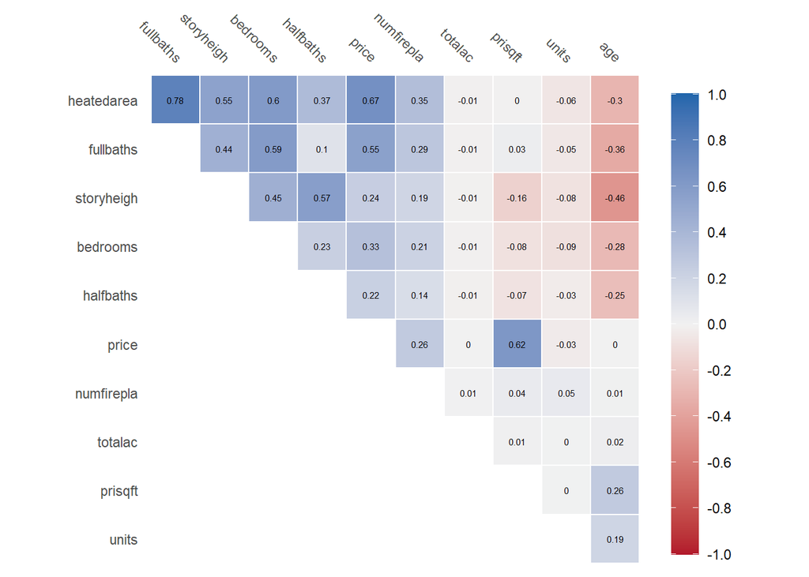

```r
# #internal features
# ggcorrplot(
#   round(cor(factor_internal), 1),
#   p.mat = cor_pmat(factor_internal),
#   colors = c('#05A167', "white", '#6897BB'),
#   type="lower",
#   insig = "blank") +
#     labs(title = "Correlation across numeric variables\n(internal features)\n",
#        caption = 'Figure DATA 2.2') +
#     plotTheme()
#
# #amenity features
# factor_amenity <-factor_amenity%>%filter(prisqft != 'Inf')
# ggcorrplot(
#   round(cor(factor_amenity), 1),
#   p.mat = cor_pmat(factor_amenity),
#   colors = c('#05A167', "white", '#6897BB'),
#   type="lower",
#   insig = "blank") +
#     labs(title = "Correlation across numeric variables\n(Amenity)\n",
#        caption = 'Figure DATA 2.3') +
#     plotTheme()
#
# ggcorrplot(
#   round(cor(factor_acs), 1),
#   p.mat = cor_pmat(factor_acs),
#   colors = c('#05A167', "white", '#6897BB'),
#   type="lower",
#   insig = "blank") +
#     labs(title = "Correlation across numeric variables\n(ACS)\n",
#        caption = 'Figure DATA 2.4')+
#     plotTheme()

factor_internal %>%
  correlate() %>%
  autoplot()+
  geom_text(aes(label = round(r,digits=2)),size = 2)
```

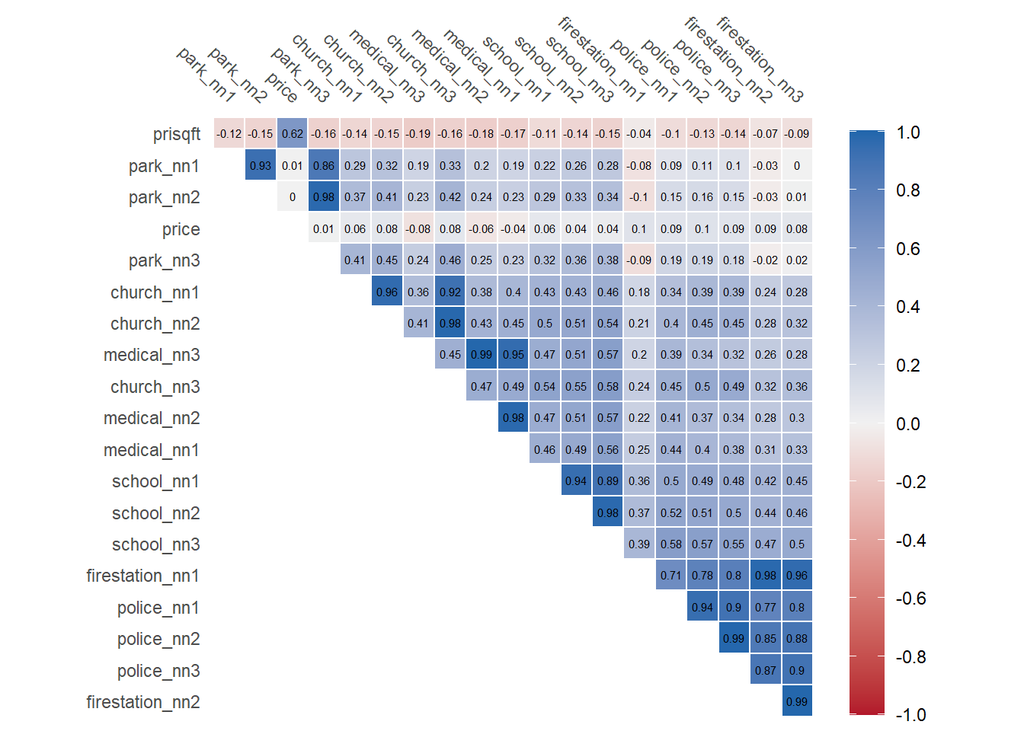

```r
factor_amenity %>%
  correlate() %>%
  autoplot() +
  geom_text(aes(label = round(r,digits=2)),size = 2)
```

**ACS data :**Some of the variables in the ACS data are also closely related to house prices. For example, in this matrix price per square feet seems to be related with percentage of white.

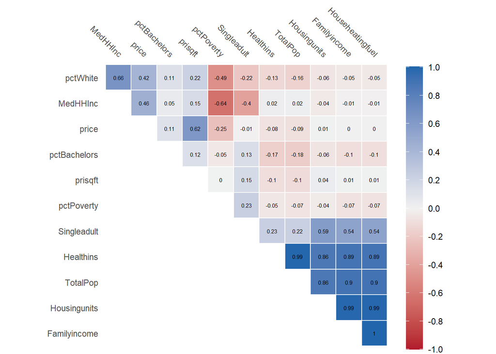

```r
factor_acs %>%
  correlate() %>%
  autoplot() +
  geom_text(aes(label = round(r,digits=2)),size = 2)
```

## 2.4 Home prices scatterplots

We present 4 home price correlation scatterplots that we think are of interest, age, bedrooms, living area and single adult. We found a positive correlation between the number of rooms, livingarea and room rates, which is also consistent with common sense. Age and single adults are negatively correlated with house prices, but the coefficients are not large. Age may be due to the fact that buildings built earlier tend to be in low quality.

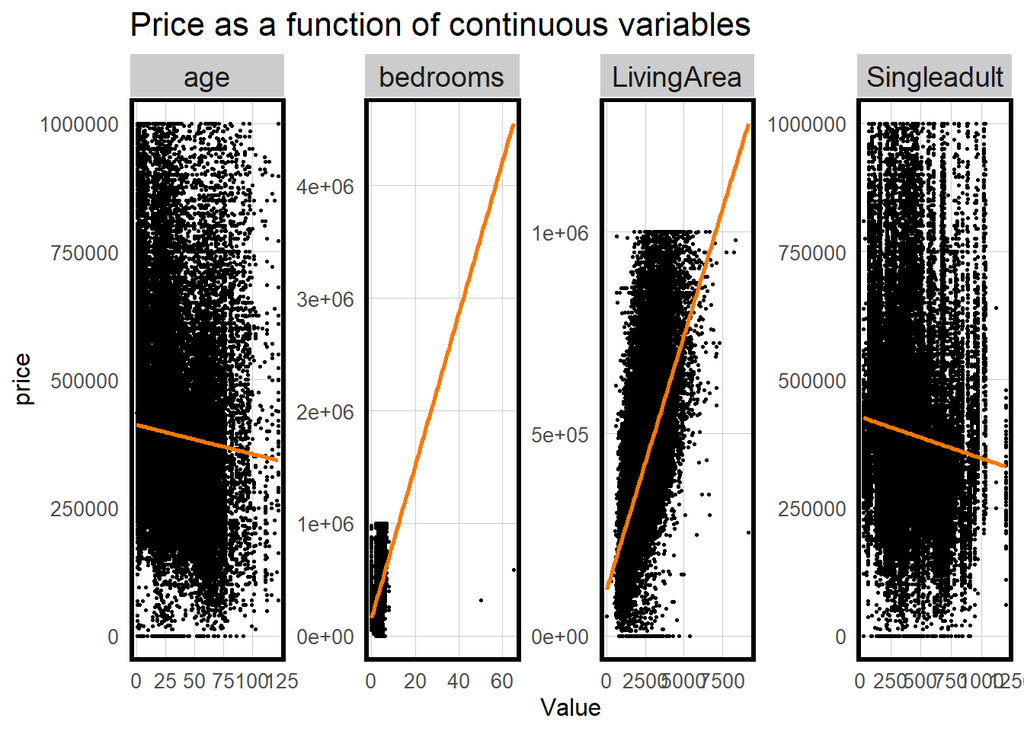

```r
## Home Features cor
st_drop_geometry(all.sf) %>%
  mutate(LivingArea = heatedarea) %>%
  dplyr::select(price, LivingArea, age,bedrooms, Singleadult) %>%
  filter(price <= 1000000, age < 500) %>%
  gather(Variable, Value, -price) %>%
   ggplot(aes(Value, price)) +
     geom_point(size = .5) + geom_smooth(method = "lm", se=F, colour = "#FA7800") +
     facet_wrap(~Variable, ncol = 4, scales = "free") +
     labs(title = "Price as a function of continuous variables") +
     plotTheme()
```

## 2.5 Map Home Prices

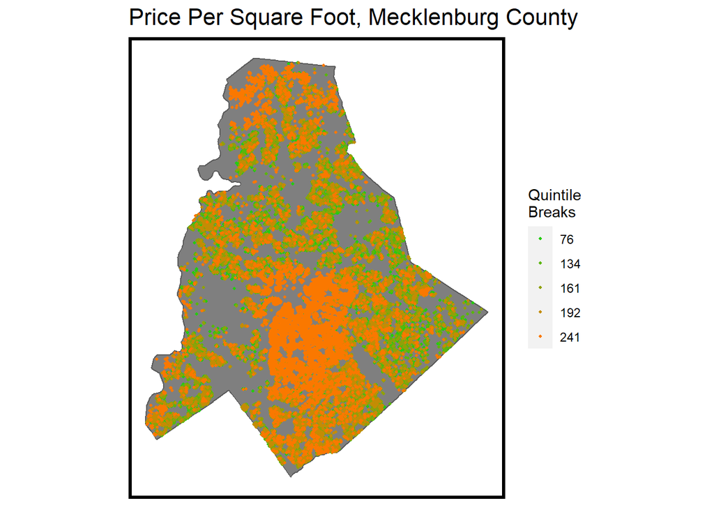

```r
maphomeprice <-topredict%>%filter(prisqft!= 'Inf')
ggplot() +
  geom_sf(data = st_union(tracts20), fill = "grey50") +
  geom_sf(data = maphomeprice, aes(colour = q5(prisqft)),
          show.legend = "point", size = .75) +
  scale_colour_manual(values = palette5,
                   labels=qBr(maphomeprice,"prisqft"),
                   name="Quintile\nBreaks") +
  labs(title="Price Per Square Foot, Mecklenburg County") +
  mapTheme()
```

## 2.6 Three interesting maps

By plotting the matrix, we choose some variables with high positive or negative correlation. **Percentage of white:**  
The first independent variables we choose is the percentage of white.As the matrix shows, percentage of white and house prices are more positively correlated.We found that both the southern and northern parts of Mecklenburg County have a higher percentage of whites, basically greater than 75%, and this all corresponds to the higher prices in the previous house price map. In contrast, the places with lower house prices have a lower percentage of whites, even below 25%.

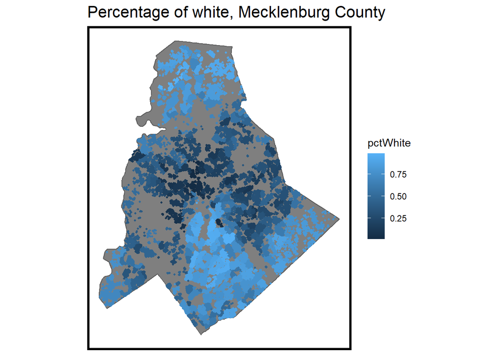

```r
# plot map of white

ggplot() +
  geom_sf(data = st_union(tracts20), fill = "grey50") +
  geom_sf(data = factor_acs.sf%>%filter(pctWhite<1), aes(colour = pctWhite),
          show.legend = "point", size = .75) +
  #scale_colour_manual(values = palette5,
                   #labels=qBr(maphomeprice,"prisqft"),
                  #name="Quintile\nBreaks") +
  labs(title="Percentage of white, Mecklenburg County") +
  mapTheme()
```

**Number of fullbaths in houses:**  
The second variable is Housing the number of full baths.We chose this variable because they have a strong correlation in the matrix, which is also in line with the general common sense inference. We can see that there are indeed more toilets in the south where the prices are higher as well.

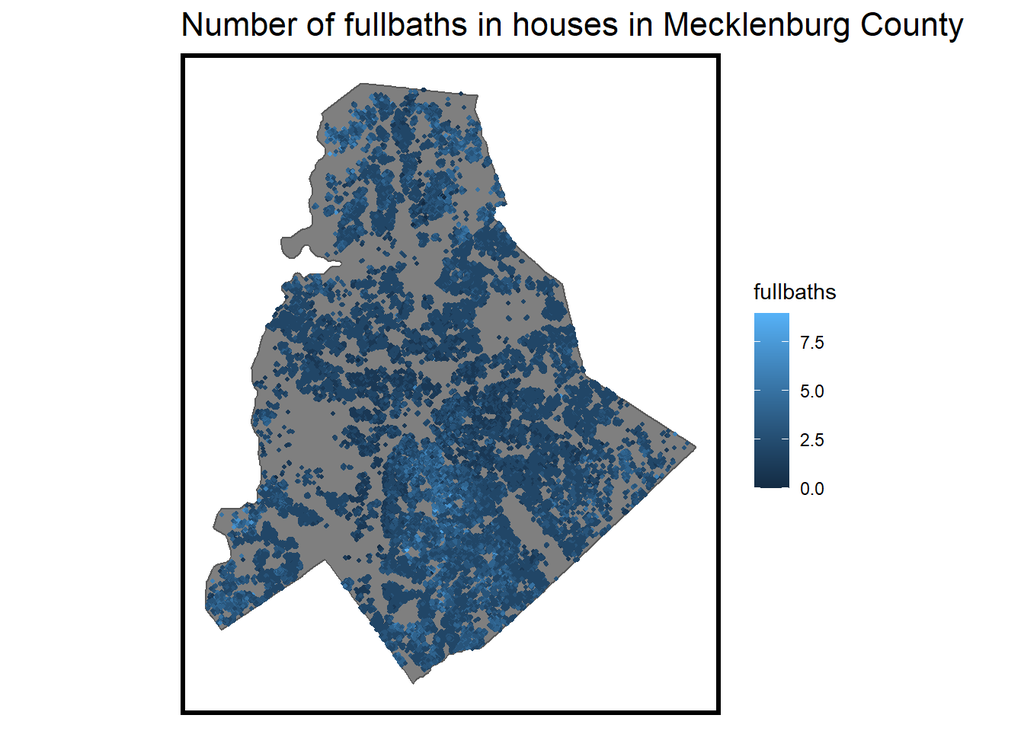

```r
# plot map of age
factor_internal.sf<-factor_internal.sf%>%filter(age != 2022)
ggplot() +
  geom_sf(data = st_union(tracts20), fill = "grey50") +
  geom_sf(data = factor_internal.sf, aes(colour = fullbaths),
          show.legend = "point", size = .75) +
  #scale_colour_manual(values = palette5,
                   #labels=qBr(maphomeprice,"prisqft"),
                   #name="Quintile\nBreaks") +
  labs(title="Number of fullbaths in houses in Mecklenburg County") +
  mapTheme()
```

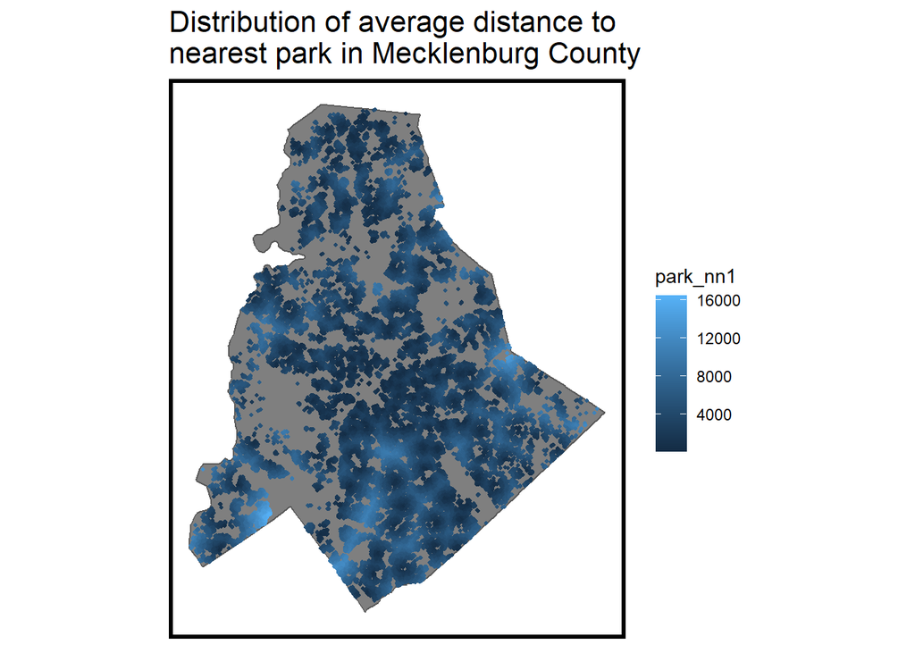

```r
# plot map of park

ggplot() +
  geom_sf(data = st_union(tracts20), fill = "grey50") +
  geom_sf(data = factor_amenity.sf, aes(colour = park_nn1),
          show.legend = "point", size = .75) +
  #scale_colour_manual(values = palette5,
                   #labels=qBr(maphomeprice,"prisqft"),
                   #name="Quintile\nBreaks") +
  labs(title="Distribution of average distance to\nnearest park in Mecklenburg County") +
  mapTheme()
```

## 2.7 Bonus for something extra engaging

**hospital**: We believe that health care resources are also an important factor in housing prices. Although the correlation is not high in the matrix, it is possible that it is influenced by hospital quality. We still find that areas with higher house prices in the south are closer to hospitals.

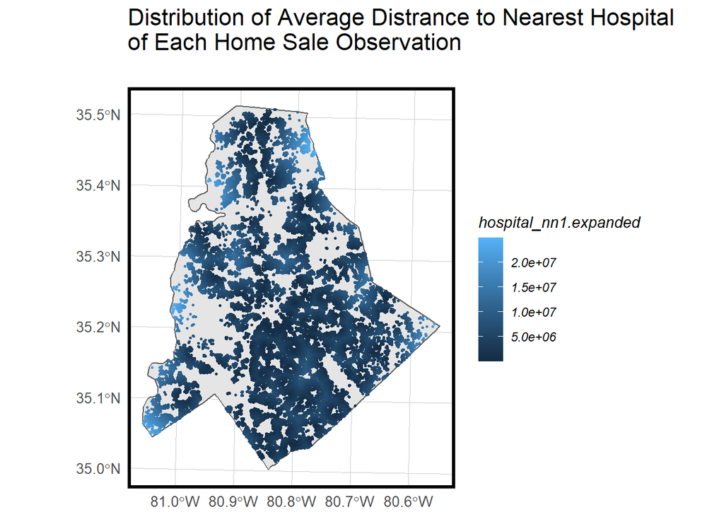

```r
hospital_nn1_expanded <- topredict %>%
  mutate(hospital_nn1.expanded = medical_nn1 * 1000)

ggplot() +
  geom_sf(data = st_union(tracts20),fill = '#E5E5E5') +
  geom_sf(data = st_centroid(hospital_nn1_expanded),aes(color = hospital_nn1.expanded),size = .5) +
  # scale_color_manual(values = palette,
  #                    labels = qBr(hospital_nn1_expanded,'hospital_nn1.expanded'),
  #                    name = "Average Distrance\nto Nearest Hospital\n(timed by 1000 \nfor better visualization)\n") +
  labs(title = 'Distribution of Average Distrance to Nearest Hospital\nof Each Home Sale Observation\n') +
  mapTheme() +
  plotTheme()
```

# III Methods

Method: The mean objective of this analysis is to train a robust model to predict house price as accurately as possible. Accordingly, this section started to provide a detailed interpretation on the process of the model building and training.

Here are three models used in this part.  
`model1`: the primitive model, where all the facotrs are in.  
`model2`: the model after training, with the facotrs selected.  
`model3`: the model to figure out the ‘challenge’

**• Data and Sample:** In order to accurately build and test models, we randomly split the whole into two parts: with 60% of observations for model training and with 40% of observations for model testing.  
**• Dependent Variable:** The dependent variable is home sale price: *Price*  
**• Independent Variables:** Based on the hedonic home price model, potential features should encompass at least three components: internal characteristics, like the number of bathrooms; neighborhood amenities/public services, like hospital accessibility; and the underlying spatial process of prices.Plus, we also take the ACS data into consideration.

**• Procedure:** The primitive approach used in this analysis for model building is Ordinary Least Squares Regression (OLS) which is aimed at predicting the of houses as a function of several statistical parameters such as intercept, slope and selected features.

In order to determine which features were able to significantly increase the accuracy and generalizability of the model, we systematically compared, plotted, and mapping the mean absolute errors (MAE), mean absolute percent errors (MAPE), as well as root mean square errors (RMSE, the standard deviation of the residuals) between original and predicted of both training set and test set, conducted the cross-validation on 100 folds, explored the underlying spatial pattern of price and errors caused by problematic prediction. To address the problem of neglecting the underlying spatial correlation caused by neighborhood, we then compared, plotted, and mapped the mean absolute errors (MAE), and mean absolute percent errors (MAPE) on the test set between baseline model without neighborhood features and updated model with neighborhood features, and then determined our final model based on series model examinations.

# IV. Result

## 4.1 Dataset Splitting and Model Building

Firstly, as mentioned above, we randomly split the variables into 60% and 40%. Secondly,we built three models with different features to examine which features should be included.

`model1`: the primitive model with baseline, where all the facotrs are in. `model2`: the model after training, with the facotrs selected. `model3`: it is based on `model2`, the function of model3 is to figure out the ‘challenge’ to complete the competition.

The baseline model contained 10 internal characteristic features: *age, storyheigh, heatedare, numfirepla, totalac, fullbaths, halfbaths, bedrooms, units, prisqft* and ,as well as 18 amenity features. Plus, there are also some ACS features.

```r
set.seed(42)

inTrain <- caret::createDataPartition(
  y = paste(topredict$name,topredict$price),
  p = .60, list = FALSE)

# split data into training and test
model.training <- topredict[inTrain,]
model.test <- topredict[-inTrain,]

## First model: All internal features, amenity features
model1 <- lm(price ~ ., data = as.data.frame(model.training) %>%
           dplyr::select(colnames(factor_internal),
                         colnames(factor_amenity),
                         colnames(factor_acs)
))

# stargazer(model1, type = "html",
#            title = "Table 4.1.1 Summary Statistics of Model 1 ",
#            #out = "model1.html",
#            header = FALSE,
#            single.row = TRUE)
```

```r
model3 <- lm(price ~ ., data = as.data.frame(topredict) %>%
           dplyr::select(# internal features
                         price,age, storyheigh,heatedarea,#prisqft,
                         numfirepla, fullbaths,halfbaths,bedrooms,
                         units,
                         # amenity features
                         police_nn1,police_nn2,police_nn3,school_nn1,
                         school_nn2,school_nn3,church_nn1,church_nn2,
                         church_nn3,park_nn1,park_nn3,firestation_nn2,
                         firestation_nn3,medical_nn2,medical_nn3,
                         #acs
                         pctWhite,pctBachelors,pctPoverty,MedHHInc,
                         Singleadult,Healthins,Familyincome
                         ))
challenge<-
  challenge %>%
  mutate(SalePrice.Predict = predict(model3,challenge))

challenge<- challenge %>%
  mutate(price=SalePrice.Predict,
         prisqft = price/heatedarea)
```

## 4.2 Table of results (training set)

```r
model2 <- lm(price ~ ., data = as.data.frame(model.training) %>%
           dplyr::select(# internal features
                         price, age, storyheigh,heatedarea, prisqft,
                         numfirepla, fullbaths,halfbaths,bedrooms,
                         units,
                         # amenity features
                         police_nn1,police_nn2,police_nn3,school_nn1,
                         school_nn2,school_nn3,church_nn1,church_nn2,
                         church_nn3,park_nn3,firestation_nn2,
                         firestation_nn3,medical_nn1,
                         #acs
                         pctWhite,pctBachelors,pctPoverty,MedHHInc,
                         Singleadult,Healthins,Familyincome
                         )

)
model.test <-
  model.test %>%
  mutate(SalePrice.Predict = predict(model2, model.test),
         SalePrice.Error = SalePrice.Predict - price,
         SalePrice.AbsError = abs(SalePrice.Predict - price),
         SalePrice.APE = (abs(SalePrice.Predict - price)) / SalePrice.Predict)%>%
  filter(price < 5000000)
```

```r
stargazer(model2, type = "html",
          title = "Table 4.1.2 Summary Statistics of Model 2 ",
          header = FALSE,
          #out = "model2.html",
          single.row = TRUE)
```

**Table 4.1.2 Summary Statistics of Model 2**

|  | *Dependent variable:* |
| --- | --- |
|  | price |
| age | 202.952*** (44.923) |
| storyheigh | -53,389.670*** (2,792.163) |
| heatedarea | 247.015*** (1.662) |
| prisqft | 2,117.438*** (9.094) |
| numfirepla | 7,346.763*** (2,213.482) |
| fullbaths | 33,980.480*** (2,035.367) |
| halfbaths | 52,451.320*** (2,297.486) |
| bedrooms | -17,336.010*** (1,162.913) |
| units | -19,394.380*** (4,619.095) |
| police_nn1 | -2.092*** (0.319) |
| police_nn2 | 9.818*** (0.925) |
| police_nn3 | -10.682*** (0.743) |
| school_nn1 | -3.998*** (0.980) |
| school_nn2 | 13.874*** (2.179) |
| school_nn3 | -8.966*** (1.667) |
| church_nn1 | -10.073*** (1.823) |
| church_nn2 | 19.892*** (4.041) |
| church_nn3 | -18.297*** (2.940) |
| park_nn3 | 5.086*** (0.437) |
| firestation_nn2 | 7.404*** (0.946) |
| firestation_nn3 | -3.523*** (1.036) |
| medical_nn1 | -1.122*** (0.288) |
| pctWhite | -32,483.920*** (5,633.095) |
| pctBachelors | -681,540.400*** (76,951.500) |
| pctPoverty | 152,606.600*** (15,849.790) |
| MedHHInc | 1.115*** (0.044) |
| Singleadult | 173.080*** (9.437) |
| Healthins | 17.852*** (2.551) |
| Familyincome | -95.006*** (9.078) |
| Constant | -507,483.900*** (9,603.819) |
| Observations | 27,781 |
| R<sup>2</sup> | 0.870 |
| Adjusted R<sup>2</sup> | 0.869 |
| Residual Std. Error | 152,455.000 (df = 27751) |
| F Statistic | 6,376.479*** (df = 29; 27751) |
| *Note:* | p<0.1; p<0.05; p<0.01 |

## 4.3 Table of goodness of fit (test set)

```r
test_fit<-as.data.frame(cbind(mean(model.test$SalePrice.AbsError,na.rm = T),
                              mean(model.test$SalePrice.APE,na.rm = T)))
colnames(test_fit)<-c("Mean Absolute Errors (MAE)","MAPE")
kable(test_fit,
      caption = 'Table RESULT. MAE and MAPE for Test Set') %>%
  kable_styling("striped", full_width = F)
```

Table RESULT. MAE and MAPE for Test Set

| Mean Absolute Errors (MAE) | MAPE |
| --- | --- |
| 67696.76 | 0.2694697 |